# R2E Tenant Management Database

Developed as part of a graduate-level Database Management course, this project involved designing and implementing a relational tenant management database for a simulated property management company. The system replaces spreadsheet-based tracking with a structured Microsoft Access database that manages properties, tenants, service requests, and employees through centralized data entry, reporting, and query-based monitoring.

**Executive Overview**

R2E, LLC is a building management company that has owned and operated several residential properties in Long Island City, Queens for the past five years. Currently, the company relies on large Excel spreadsheets to track properties, tenants, service requests, and employees. As the business has grown, these spreadsheets have become increasingly difficult to manage, leading to inefficiencies, limited visibility into operations, and higher risk of data errors. To address this, the goal of this project was to design and implement a centralized relational database using Microsoft Access to replace the existing manual tracking system.

R2E owns multiple buildings, each containing several apartment units. Every unit can be rented to one primary tenant, although multiple occupants may reside in the same apartment under a single lease. The system must track unit occupancy status (occupied or vacant), tenant information such as name, contact details, and household size, and maintain clear relationships between properties, units, and tenants.

In addition to tenant management, R2E provides in-house repair and maintenance services, including appliance repairs, plumbing issues, and leak resolution. The database must record which apartment submitted a service request, the type of issue reported, and the employee assigned to resolve it. While employees may handle multiple service requests over time, each individual request is assigned to a single employee to ensure accountability and tracking.

The system also maintains detailed employee records, including contact information, home address, and job role, enabling accurate service assignment and operational oversight. Overall, the database is designed to improve data organization, increase operational efficiency, and provide structured reporting to support better management decisions.

**Entity Relationship Diagram**

[figure not shown]

**System Features & Workflows**

**Data Entry & Navigation (Forms):**

1. *Switchboard (Main Navigation)*

The Switchboard serves as the central navigation interface of the database. It provides structured access to data entry forms and reporting modules, allowing users to efficiently manage tenant records, service requests, and employee information. By organizing workflows into clear menu paths, the Switchboard improves usability and reduces operational confusion.

[figure not shown]

2. *Service Request Form:*

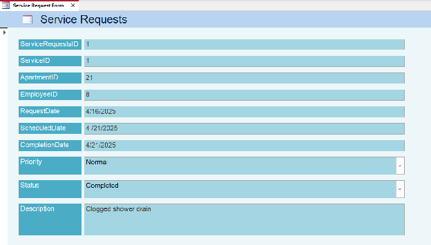

3. *New Tenant Form:*

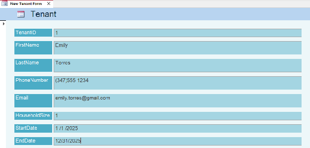

4. *New Employee Form:*

The New Employee Form is a comprehensive onboarding form that will help building management collect essential information for newly hired staff. This form requests key details such as the employee’s full name, job position, phone number, email address, and address. This form will play an essential role to enable the management team to maintain organized employee profiles and streamline onboarding processes.

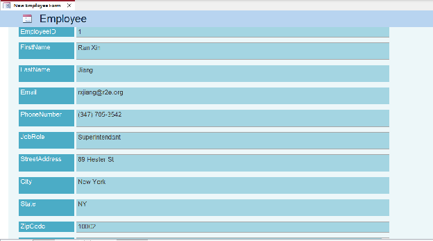

**Operational Monitoring & Reporting:**

1. *Tenant Directory Report:*

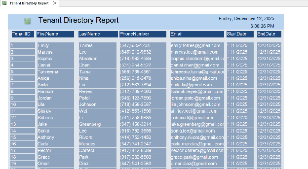

2. *Property Maintenance & Service Request Report:*

The Property Maintenance & Service Request Report provides an overview of all maintenance activity across each property, including the number and types of service requests submitted monthly and the average time taken to complete them. By tracking completion speed, identifying recurring issues, and highlighting properties with unusually high request volumes, this report helps management spot problem areas, prioritize repairs, and determine when more significant actions, such as preventative maintenance or renovations, may be needed.

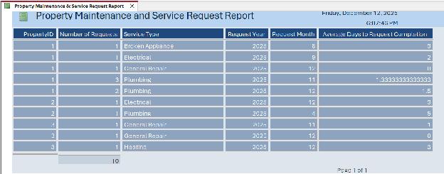

3. *Employee Performance Report:*

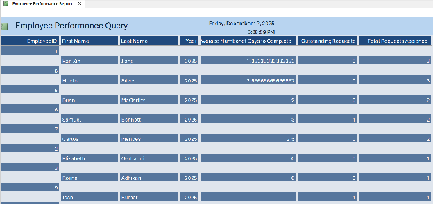

4. *Open Service Request Report:*

The Open Service Request Report provides real-time visibility into unresolved maintenance tasks across properties. It displays submission date, service type, assigned employee, and current status, allowing management to identify delays and ensure timely resolution.

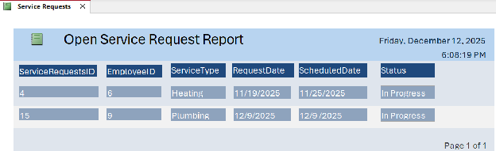

**Analytical & Tracking Queries:**

1. *Open Service Requests Query:*

Open Service Requests Query identifies all service requests that are currently open and not yet completed. It provides management with real-time visibility into outstanding maintenance issues, helping them prioritize urgent requests, monitor workload distribution, and ensure no requests are overlooked.

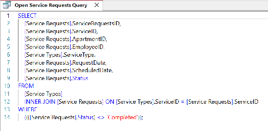

2. *Completed Service Requests Details Query:*

Completed Service Requests Details Query retrieves completed service requests along with the service type, assigned employee, apartment ID, and total completion time. It allows management to evaluate employee responsiveness, track operational efficiency, and assess whether service tasks are being completed within a reasonable timeframe.

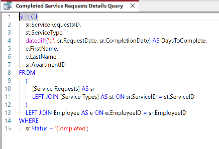

3. *Average Service Request Completion Query*

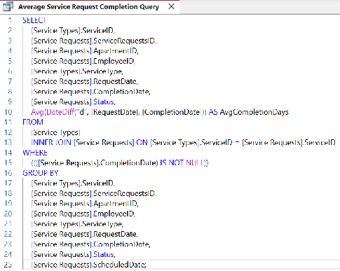

4. *Property Maintenance & Service Request Query*

Property Maintenance & Service Request Query summarizes the total number of service requests received per property each month and the average days required for completion, grouped by service type. This helps management compare property-level performance, detect recurring maintenance patterns, and make more data-driven decisions regarding preventative maintenance planning and resource allocation.

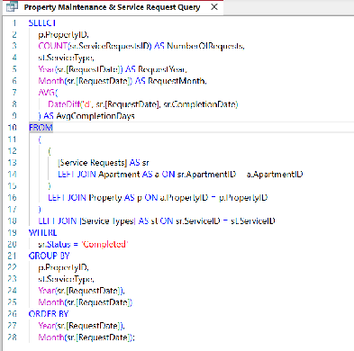